# Causal Inference Assignment

# Population diagnostic plots

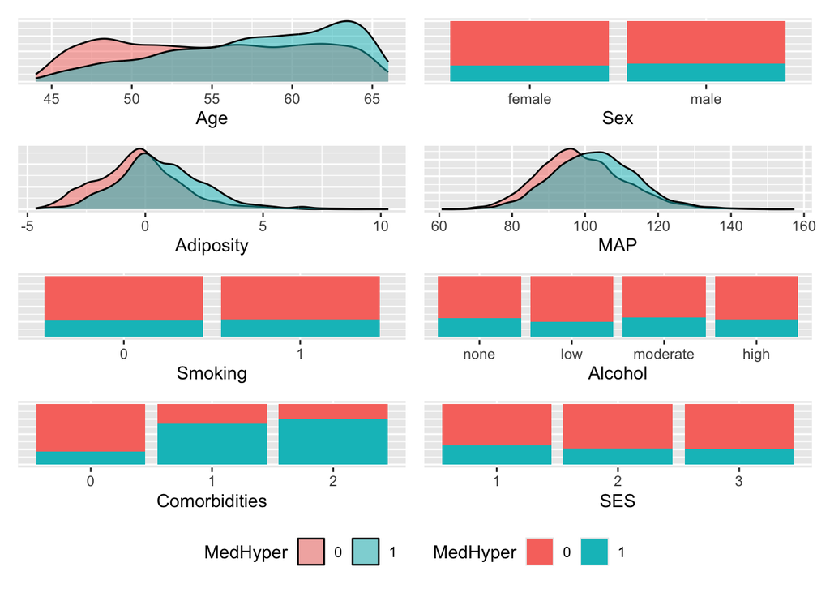

```r
# Age
p1 <- ggplot(data, aes(x = age, fill = factor(medhyper))) +
  geom_density(alpha = 0.5) +
  labs(x = "Age") +
  scale_fill_manual(
    name = "MedHyper",
    values = c("0" = "#F8766D", "1" = "#00BFC4")) +
  theme(legend.position = "none",
        axis.title.y = element_blank(),
        axis.text.y = element_blank(),
        axis.ticks.y = element_blank())

# Sex
p2 <- ggplot(data, aes(x = factor(sex), fill = factor(medhyper))) +
  geom_bar(position = "fill") +
  labs(x = "Sex") +
  scale_fill_manual(
    name = "MedHyper",
    values = c("0" = "#F8766D", "1" = "#00BFC4")) +
  theme(legend.position = "none",
        axis.title.y = element_blank(),
        axis.text.y = element_blank(),
        axis.ticks.y = element_blank())


# Adiposity
p3 <- ggplot(data, aes(x = adiposity, fill = factor(medhyper))) +
  geom_density(alpha = 0.5) +
  labs(x = "Adiposity") +
  scale_fill_manual(
    name = "MedHyper",
    values = c("0" = "#F8766D", "1" = "#00BFC4")) +
  theme(legend.position = "none",
        axis.title.y = element_blank(),
        axis.text.y = element_blank(),
        axis.ticks.y = element_blank())


# MAP
p4 <- ggplot(data, aes(x = MAP, fill = factor(medhyper))) +
  geom_density(alpha = 0.5) +
  labs(x = "MAP") +
  scale_fill_manual(
    name = "MedHyper",
    values = c("0" = "#F8766D", "1" = "#00BFC4")) +
  theme(legend.position = "none",
        axis.title.y = element_blank(),
        axis.text.y = element_blank(),
        axis.ticks.y = element_blank())

# Smoking
p5 <- ggplot(data, aes(x = factor(current.smoking), fill = factor(medhyper))) +
  geom_bar(position = "fill") +
  labs(x = "Smoking") +
  scale_fill_manual(
    name = "MedHyper",
    values = c("0" = "#F8766D", "1" = "#00BFC4")) +
  theme(legend.position = "none",
        axis.title.y = element_blank(),
        axis.text.y = element_blank(),
        axis.ticks.y = element_blank())

# Alcohol
p6 <- ggplot(data, aes(x = factor(alcohol), fill = factor(medhyper))) +
  geom_bar(position = "fill") +
  labs(x = "Alcohol") +
  scale_fill_manual(
    name = "MedHyper",
    values = c("0" = "#F8766D", "1" = "#00BFC4")) +
  theme(legend.position = "none",
        axis.title.y = element_blank(),
        axis.text.y = element_blank(),
        axis.ticks.y = element_blank())

# Comorbidities
p7 <- ggplot(data, aes(x = factor(comorbidities), fill = factor(medhyper))) +
  geom_bar(position = "fill") +
  labs(x = "Comorbidities") +
  scale_fill_manual(
    name = "MedHyper",
    values = c("0" = "#F8766D", "1" = "#00BFC4")) +
  theme(legend.position = "none",
        axis.title.y = element_blank(),
        axis.text.y = element_blank(),
        axis.ticks.y = element_blank())

# SES
p8 <- ggplot(data, aes(x = factor(SES), fill = factor(medhyper))) +
  geom_bar(position = "fill") +
  labs(x = "SES") +
  scale_fill_manual(
    name = "MedHyper",
    values = c("0" = "#F8766D", "1" = "#00BFC4")) +
  theme(legend.position = "none",
        axis.title.y = element_blank(),
        axis.text.y = element_blank(),
        axis.ticks.y = element_blank())

# Combine plots
pop_plots <- list(p1, p2, p3, p4, p5, p6, p7, p8)
wrap_plots(pop_plots, nrow = 4) +
plot_layout(guides = "collect") &
theme(legend.position = "bottom")
```

# DAG

## Postulated DAG

We start by postulating a DAG given literature-backed expert knowledge, which should comprehensively include all causal pathways between our covariates.

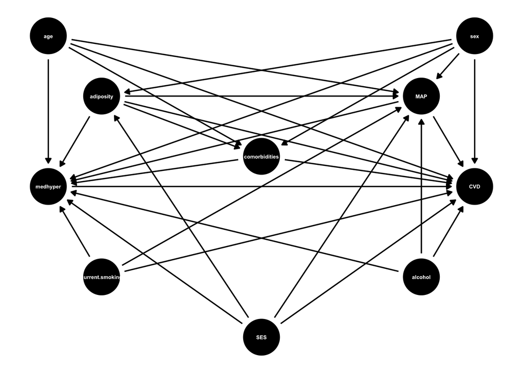

```r
obesity_dag <- dagify(
  comorbidities ~ age + adiposity + sex,
  adiposity ~ sex + SES,
  MAP ~ age + sex + adiposity + current.smoking + alcohol + SES,
  medhyper ~ MAP + SES + age + sex + current.smoking + alcohol + adiposity + comorbidities,
  CVD ~ age + sex + current.smoking + alcohol + adiposity + MAP + medhyper + SES + comorbidities,

  exposure = "medhyper",
  outcome = "CVD",

  coords = list(
    x = c(
      age = 2,
      sex = 6,
      current.smoking = 2.5,
      alcohol = 5.5,
      adiposity = 2.5,
      SES = 4,
      MAP = 5.5,
      medhyper = 2,
      CVD = 6,
      comorbidities = 4
    ),

    y = c(
      age = 5,
      sex = 5,
      current.smoking = 1,
      alcohol = 1,
      adiposity = 4,
      SES = 0,
      MAP = 4,
      medhyper = 2.5,
      CVD = 2.5,
      comorbidities = 3
    )
  )
)

# Plot DAG
ggdag(obesity_dag, text_size = 1.8) +
  theme(
    axis.title.x = element_blank(),
    axis.text.x = element_blank(),
    axis.ticks.x = element_blank(),
    axis.title.y = element_blank(),
    axis.text.y = element_blank(),
    axis.ticks.y = element_blank(),
    panel.background = element_blank())
```

## DAG pruning

As we used a very conservative approach when postulating our DAG, we see if any causal pathways are actually mediated by other variables rather than have direct links. We will make assumptions and test implied conditional dependencies to see if the data we have supports those assumptions. If supported, those causal pathways will be removed from the final DAG.

### Social factors to medhyper

We assume that the effects of socio-economic status (SES), alcohol and smoking status on antihypertensive medications might be fully mediated by mean arterial blood pressure (MAP).

```r
pruned_dag <- dagify(
  comorbidities ~ age + adiposity + sex,
  adiposity ~ sex + SES,
  MAP ~ age + sex + adiposity + current.smoking + alcohol + SES,
  medhyper ~ MAP + age + sex + adiposity + comorbidities,
  CVD ~ age + sex + current.smoking + alcohol + adiposity + MAP + medhyper + SES + comorbidities,

  exposure = "medhyper",
  outcome = "CVD",

  coords = list(
    x = c(
      age = 2,
      sex = 6,
      current.smoking = 2.5,
      alcohol = 5.5,
      adiposity = 2.5,
      SES = 4,
      MAP = 5.5,
      medhyper = 2,
      CVD = 6,
      comorbidities = 4
    ),

    y = c(
      age = 5,
      sex = 5,
      current.smoking = 1,
      alcohol = 1,
      adiposity = 4,
      SES = 0,
      MAP = 4,
      medhyper = 2.5,
      CVD = 2.5,
      comorbidities = 3
    )
  )
)
# Run local tests to see if data supports assumptions
r <- localTests(pruned_dag, data, type = "cis.pillai")
# Retain only those tests with adjusted p-value < .05
r <- r[p.adjust(r$p.value) < 0.05, ]
r
```

```
##                                         estimate      p.value        2.5%
## SES _||_ age                          0.03979461 3.431217e-04  0.03979461
## SES _||_ alch                         0.08820877 0.000000e+00  0.08820877
## SES _||_ cmrb | adps, sex             0.03127089 5.725618e-04  0.03127089
## SES _||_ crr.                         0.05576063 1.557862e-07  0.05576063
## SES _||_ sex                          0.23437855 0.000000e+00  0.23437855
## adps _||_ alch                        0.09657458 0.000000e+00  0.09657458
## age _||_ alch                         0.14532524 0.000000e+00  0.14532524
## age _||_ crr.                         0.06283315 2.777380e-10  0.04335453
## age _||_ sex                          0.03144677 1.599200e-03  0.01192226
## alch _||_ cmrb                        0.07249455 0.000000e+00  0.07249455
## alch _||_ crr.                        0.11989118 0.000000e+00  0.11989118
## alch _||_ mdhy | MAP, adps, age, sex  0.06458069 3.873804e-09  0.06458069
## alch _||_ sex                         0.30382094 0.000000e+00  0.30382094
## crr. _||_ sex                        -0.05410572 5.548238e-08 -0.07355981
##                                            97.5%
## SES _||_ age                          0.03979461
## SES _||_ alch                         0.08820877
## SES _||_ cmrb | adps, sex             0.03127089
## SES _||_ crr.                         0.05576063
## SES _||_ sex                          0.23437855
## adps _||_ alch                        0.09657458
## age _||_ alch                         0.14532524
## age _||_ crr.                         0.08226401
## age _||_ sex                          0.05094730
## alch _||_ cmrb                        0.07249455
## alch _||_ crr.                        0.11989118
## alch _||_ mdhy | MAP, adps, age, sex  0.06458069
## alch _||_ sex                         0.30382094
## crr. _||_ sex                        -0.03461047
```

The data we have supports the assumption that SES and smoking status are mediated via other variables, we therefore are able to prune those arrows. However, we also found that the relationship between alcohol and medhyper is significant, we therefore retain that causal pathway in our DAG.

### Biological factors to medhyper

We assume that adiposity may not be directly linked to medhyper but could be mediated via MAP or comorbidities.

```r
pruned_dag <- dagify(
  comorbidities ~ age + adiposity + sex,
  adiposity ~ sex + SES,
  MAP ~ age + sex + adiposity + current.smoking + alcohol + SES,
  medhyper ~ MAP + age + sex + comorbidities + alcohol,
  CVD ~ age + sex + current.smoking + alcohol + adiposity + MAP + medhyper + SES + comorbidities,

  exposure = "medhyper",
  outcome = "CVD",

  coords = list(
    x = c(
      age = 2,
      sex = 6,
      current.smoking = 2.5,
      alcohol = 5.5,
      adiposity = 2.5,
      SES = 4,
      MAP = 5.5,
      medhyper = 2,
      CVD = 6,
      comorbidities = 4
    ),

    y = c(
      age = 5,
      sex = 5,
      current.smoking = 1,
      alcohol = 1,
      adiposity = 4,
      SES = 0,
      MAP = 4,
      medhyper = 2.5,
      CVD = 2.5,
      comorbidities = 3
    )
  )
)

r <- localTests(pruned_dag, data, type = "cis.pillai")
## Retain only those tests with adjusted p-value < .05
r <- r[p.adjust(r$p.value) < 0.05, ]
r
```

```
##                                               estimate      p.value        2.5%
## SES _||_ age                                0.03979461 3.431217e-04  0.03979461
## SES _||_ alch                               0.08820877 0.000000e+00  0.08820877
## SES _||_ cmrb | adps, sex                   0.03127089 5.725618e-04  0.03127089
## SES _||_ crr.                               0.05576063 1.557862e-07  0.05576063
## SES _||_ sex                                0.23437855 0.000000e+00  0.23437855
## adps _||_ alch                              0.09657458 0.000000e+00  0.09657458
## adps _||_ mdhy | MAP, age, alch, cmrb, sex  0.17066569 1.104141e-66  0.15163934
## age _||_ alch                               0.14532524 0.000000e+00  0.14532524
## age _||_ crr.                               0.06283315 2.777380e-10  0.04335453
## age _||_ sex                                0.03144677 1.599200e-03  0.01192226
## alch _||_ cmrb                              0.07249455 0.000000e+00  0.07249455
## alch _||_ crr.                              0.11989118 0.000000e+00  0.11989118
## alch _||_ sex                               0.30382094 0.000000e+00  0.30382094
## crr. _||_ sex                              -0.05410572 5.548238e-08 -0.07355981
##                                                  97.5%
## SES _||_ age                                0.03979461
## SES _||_ alch                               0.08820877
## SES _||_ cmrb | adps, sex                   0.03127089
## SES _||_ crr.                               0.05576063
## SES _||_ sex                                0.23437855
## adps _||_ alch                              0.09657458
## adps _||_ mdhy | MAP, age, alch, cmrb, sex  0.18956562
## age _||_ alch                               0.14532524
## age _||_ crr.                               0.08226401
## age _||_ sex                                0.05094730
## alch _||_ cmrb                              0.07249455
## alch _||_ crr.                              0.11989118
## alch _||_ sex                               0.30382094
## crr. _||_ sex                              -0.03461047
```

As the data does not support the assumption that the causal effect of adiposity is entirely mediated via other variables, we retain the arrow in our final DAG.

### Social factors on CVD

SES, smoking, alcohol might not be a direct causes for CVD but instead be dependent on comorbidity, MAP and adiposity.

```r
pruned_dag <- dagify(
  comorbidities ~ age + adiposity + sex,
  adiposity ~ sex + SES,
  MAP ~ age + sex + adiposity + current.smoking + alcohol + SES,
  medhyper ~ MAP + age + sex + comorbidities + alcohol + adiposity,
  CVD ~ age + sex + adiposity + MAP + medhyper + comorbidities,

  exposure = "medhyper",
  outcome = "CVD",

  coords = list(
    x = c(
      age = 2,
      sex = 6,
      current.smoking = 2.5,
      alcohol = 5.5,
      adiposity = 2.5,
      SES = 4,
      MAP = 5.5,
      medhyper = 2,
      CVD = 6,
      comorbidities = 4
    ),

    y = c(
      age = 5,
      sex = 5,
      current.smoking = 1,
      alcohol = 1,
      adiposity = 4,
      SES = 0,
      MAP = 4,
      medhyper = 2.5,
      CVD = 2.5,
      comorbidities = 3
    )
  )
)

r <- localTests(pruned_dag, data, type = "cis.pillai")
## Retain only those tests with adjusted p-value < .05
r <- r[p.adjust(r$p.value) < 0.05, ]
r
```

```
##                                                    estimate      p.value
## CVD _||_ crr. | MAP, adps, age, alch, sex        0.05348042 7.877837e-08
## CVD _||_ crr. | MAP, adps, age, cmrb, mdhy, sex  0.05465726 4.059486e-08
## SES _||_ age                                     0.03979461 3.431217e-04
## SES _||_ alch                                    0.08820877 0.000000e+00
## SES _||_ cmrb | adps, sex                        0.03127089 5.725618e-04
## SES _||_ crr.                                    0.05576063 1.557862e-07
## SES _||_ sex                                     0.23437855 0.000000e+00
## adps _||_ alch                                   0.09657458 0.000000e+00
## age _||_ alch                                    0.14532524 0.000000e+00
## age _||_ crr.                                    0.06283315 2.777380e-10
## age _||_ sex                                     0.03144677 1.599200e-03
## alch _||_ cmrb                                   0.07249455 0.000000e+00
## alch _||_ crr.                                   0.11989118 0.000000e+00
## alch _||_ sex                                    0.30382094 0.000000e+00
## crr. _||_ sex                                   -0.05410572 5.548238e-08
##                                                        2.5%       97.5%
## CVD _||_ crr. | MAP, adps, age, alch, sex        0.03398410  0.07293606
## CVD _||_ crr. | MAP, adps, age, cmrb, mdhy, sex  0.03516297  0.07410997
## SES _||_ age                                     0.03979461  0.03979461
## SES _||_ alch                                    0.08820877  0.08820877
## SES _||_ cmrb | adps, sex                        0.03127089  0.03127089
## SES _||_ crr.                                    0.05576063  0.05576063
## SES _||_ sex                                     0.23437855  0.23437855
## adps _||_ alch                                   0.09657458  0.09657458
## age _||_ alch                                    0.14532524  0.14532524
## age _||_ crr.                                    0.04335453  0.08226401
## age _||_ sex                                     0.01192226  0.05094730
## alch _||_ cmrb                                   0.07249455  0.07249455
## alch _||_ crr.                                   0.11989118  0.11989118
## alch _||_ sex                                    0.30382094  0.30382094
## crr. _||_ sex                                   -0.07355981 -0.03461047
```

```r
# data supports removing SES->CVD and alcohol->CVD, but not smoking -> CVD
```

The data we have supports the assumptions that SES and alcohol are mediated via other variables, we therefore prune those causal pathways, while retaining smoking status.

### Biological factors on CVD

We assume that age and sex may not be direct causes for CVD but may be mediated by comorbidity, MAP and adiposity.

```r
pruned_dag <- dagify(
  comorbidities ~ age + adiposity + sex,
  adiposity ~ sex + SES,
  MAP ~ age + sex + adiposity + current.smoking + alcohol + SES,
  medhyper ~ MAP + age + sex + comorbidities + alcohol + adiposity,
  CVD ~ adiposity + MAP + medhyper + comorbidities + current.smoking,

  exposure = "medhyper",
  outcome = "CVD",

  coords = list(
    x = c(
      age = 2,
      sex = 6,
      current.smoking = 2.5,
      alcohol = 5.5,
      adiposity = 2.5,
      SES = 4,
      MAP = 5.5,
      medhyper = 2,
      CVD = 6,
      comorbidities = 4
    ),

    y = c(
      age = 5,
      sex = 5,
      current.smoking = 1,
      alcohol = 1,
      adiposity = 4,
      SES = 0,
      MAP = 4,
      medhyper = 2.5,
      CVD = 2.5,
      comorbidities = 3
    )
  )
)

r <- localTests(pruned_dag, data, type = "cis.pillai")
## Retain only those tests with adjusted p-value < .05
r <- r[p.adjust(r$p.value) < 0.05, ]
r
```

```
##                                               estimate      p.value        2.5%
## CVD _||_ age | MAP, adps, cmrb, crr., mdhy  0.12677932 2.343953e-37  0.10751372
## CVD _||_ sex | MAP, adps, cmrb, crr., mdhy  0.03357951 7.510956e-04  0.01405690
## SES _||_ age                                0.03979461 3.431217e-04  0.03979461
## SES _||_ alch                               0.08820877 0.000000e+00  0.08820877
## SES _||_ cmrb | adps, sex                   0.03127089 5.725618e-04  0.03127089
## SES _||_ crr.                               0.05576063 1.557862e-07  0.05576063
## SES _||_ sex                                0.23437855 0.000000e+00  0.23437855
## adps _||_ alch                              0.09657458 0.000000e+00  0.09657458
## age _||_ alch                               0.14532524 0.000000e+00  0.14532524
## age _||_ crr.                               0.06283315 2.777380e-10  0.04335453
## age _||_ sex                                0.03144677 1.599200e-03  0.01192226
## alch _||_ cmrb                              0.07249455 0.000000e+00  0.07249455
## alch _||_ crr.                              0.11989118 0.000000e+00  0.11989118
## alch _||_ sex                               0.30382094 0.000000e+00  0.30382094
## crr. _||_ sex                              -0.05410572 5.548238e-08 -0.07355981
##                                                  97.5%
## CVD _||_ age | MAP, adps, cmrb, crr., mdhy  0.14594973
## CVD _||_ sex | MAP, adps, cmrb, crr., mdhy  0.05307652
## SES _||_ age                                0.03979461
## SES _||_ alch                               0.08820877
## SES _||_ cmrb | adps, sex                   0.03127089
## SES _||_ crr.                               0.05576063
## SES _||_ sex                                0.23437855
## adps _||_ alch                              0.09657458
## age _||_ alch                               0.14532524
## age _||_ crr.                               0.08226401
## age _||_ sex                                0.05094730
## alch _||_ cmrb                              0.07249455
## alch _||_ crr.                              0.11989118
## alch _||_ sex                               0.30382094
## crr. _||_ sex                              -0.03461047
```

As the data does not support the assumption that the causal effect of age and sex are entirely mediated via other variables, we therefore retain the arrow in our final DAG.

## Final DAG

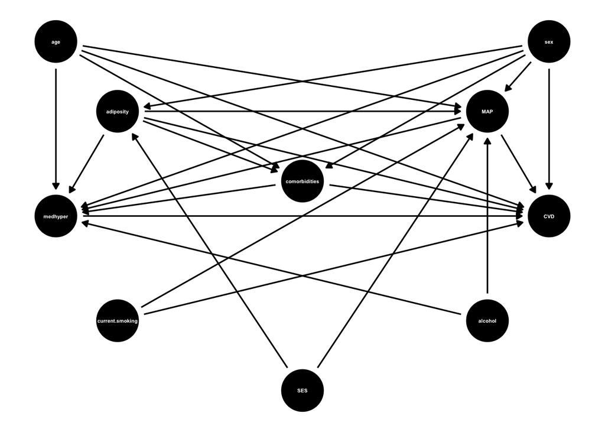

```r
# Prepare DAG object
obesity_dag <- dagify(
  comorbidities ~ age + adiposity + sex,
  adiposity ~ sex + SES,
  MAP ~ age + sex + adiposity + current.smoking + alcohol + SES,
  medhyper ~ MAP + age + sex + comorbidities + alcohol + adiposity,
  CVD ~ age + sex + adiposity + MAP + medhyper + comorbidities + current.smoking,

  exposure = "medhyper",
  outcome = "CVD",

  coords = list(
    x = c(
      age = 2,
      sex = 6,
      current.smoking = 2.5,
      alcohol = 5.5,
      adiposity = 2.5,
      SES = 4,
      MAP = 5.5,
      medhyper = 2,
      CVD = 6,
      comorbidities = 4
    ),

    y = c(
      age = 5,
      sex = 5,
      current.smoking = 1,
      alcohol = 1,
      adiposity = 4,
      SES = 0,
      MAP = 4,
      medhyper = 2.5,
      CVD = 2.5,
      comorbidities = 3
    )
  )
)

# Plot DAG
ggdag(obesity_dag, text_size = 1.5) +
  theme(
    axis.title.x = element_blank(),
    axis.text.x = element_blank(),
    axis.ticks.x = element_blank(),
    axis.title.y = element_blank(),
    axis.text.y = element_blank(),
    axis.ticks.y = element_blank(),
    panel.background = element_blank())
```

```r
# Find adjustment sets
adjustmentSets(obesity_dag)
```

```
## { MAP, adiposity, age, comorbidities, current.smoking, sex }
## { MAP, adiposity, age, alcohol, comorbidities, sex }
```

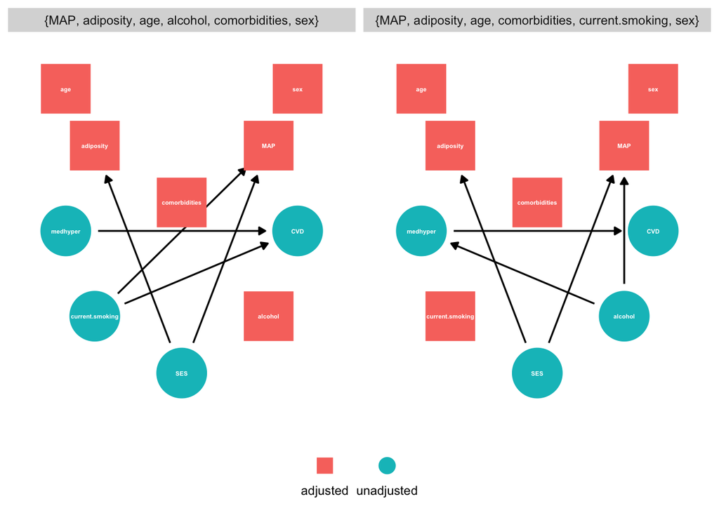

```r
# Plot adjustment sets
ggdag_adjustment_set(
  obesity_dag,
  text = TRUE,
  text_size = 1.5) +
  guides(color = guide_legend(override.aes = list(size = 5))) +
  theme(
    legend.position = "bottom",
    legend.text.position = "bottom",
    legend.title = element_blank(),
    axis.title.x = element_blank(),
    axis.text.x = element_blank(),
    axis.ticks.x = element_blank(),
    axis.title.y = element_blank(),
    axis.text.y = element_blank(),
    axis.ticks.y = element_blank(),
    panel.background = element_blank()
    )
```

Since we have two adjustment sets available, one with alcohol and one with smoking status, we chose to use the smoking status one, as the alcohol variable was transformed and therefore less reliable since more assumptions would be implied.

# G-computation

Based on our DAG, our adjustment set includes age, sex, adiposity, MAP, comorbidities, and current smoking. We fit a logistic regression model for our outcome (CVD), including interaction terms between the treatment (medhyper) and all covariates to allow the treatment effect to vary across different patient profiles.

```r
# Step 1: G-formula
g_model = glm(CVD ~ medhyper +
            age + medhyper*age +
            adiposity + medhyper*adiposity +
            MAP + medhyper*MAP +
            comorbidities + medhyper*comorbidities +
            sex + medhyper*sex +
            current.smoking + medhyper*current.smoking,
            data = data, family = binomial)
summary(g_model)
```

```
##
## Call:
## glm(formula = CVD ~ medhyper + age + medhyper * age + adiposity +
##     medhyper * adiposity + MAP + medhyper * MAP + comorbidities +
##     medhyper * comorbidities + sex + medhyper * sex + current.smoking +
##     medhyper * current.smoking, family = binomial, data = data)
##
## Coefficients:
##                           Estimate Std. Error z value Pr(>|z|)
## (Intercept)              -7.978451   0.409966 -19.461  < 2e-16 ***
## medhyper                  0.033808   0.804298   0.042 0.966472
## age                       0.060219   0.005678  10.606  < 2e-16 ***
## adiposity                 0.107909   0.018485   5.838 5.29e-09 ***
## MAP                       0.024955   0.002801   8.909  < 2e-16 ***
## comorbidities1            0.064860   0.131011   0.495 0.620546
## comorbidities2           -0.113912   0.298680  -0.381 0.702917
## sexmale                   0.225565   0.066821   3.376 0.000736 ***
## current.smoking           0.459269   0.101212   4.538 5.69e-06 ***
## medhyper:age              0.004954   0.010863   0.456 0.648338
## medhyper:adiposity       -0.045465   0.030421  -1.495 0.135039
## medhyper:MAP             -0.002706   0.004935  -0.548 0.583476
## medhyper:comorbidities1  -0.028106   0.168822  -0.166 0.867775
## medhyper:comorbidities2  -0.055386   0.349740  -0.158 0.874169
## medhyper:sexmale         -0.109004   0.116037  -0.939 0.347529
## medhyper:current.smoking  0.022111   0.178012   0.124 0.901151
## ---
## Signif. codes:  0 '***' 0.001 '**' 0.01 '*' 0.05 '.' 0.1 ' ' 1
##
## (Dispersion parameter for binomial family taken to be 1)
##
##     Null deviance: 9446.4  on 10069  degrees of freedom
## Residual deviance: 8957.1  on 10054  degrees of freedom
## AIC: 8989.1
##
## Number of Fisher Scoring iterations: 5
```

```r
# Step 2: simulate what would happen if everyone was treated vs nobody was treated

# Everyone is treated
obesity1 = data
obesity1$medhyper = 1
YE1 = predict(g_model, newdata = obesity1, type="response")
mean_YE1 = mean(YE1, na.rm = T)

# Nobody is treated
obesity0 = data
obesity0$medhyper = 0
YE0 = predict(g_model, newdata = obesity0, type="response")
mean_YE0 = mean(YE0, na.rm = T)

# Step 3: ATE + causal odds ratio
mean_YE1- mean_YE0 #average treatment effect (ATE)
```

```
## [1] -0.001909281
```

```r
(mean_YE1/(1-mean_YE1))/(mean_YE0/(1-mean_YE0)) #causal odds ratio
```

```
## [1] 0.9871314
```

## Confidence interval via bootstrap

```r
set.seed(123)
B = 1000
ATE_boot = numeric(B)
OR_boot  = numeric(B)

n = nrow(data)

for (b in 1:B) {

  #Resample data
  index = sample(1:n, n, replace = TRUE)
  data_b = data[index, ]

  #Refit model
g_model_b = glm(CVD ~ medhyper +
            age + medhyper*age +
            adiposity + medhyper*adiposity +
            MAP + medhyper*MAP +
            comorbidities + medhyper*comorbidities,
          data = data_b, family = binomial)
  #Predict medhyper = 1
  data1 = data_b
  data1$medhyper = 1
  p1 = predict(g_model_b, newdata = data1, type="response")
  m1 = mean(p1, na.rm = T)

  #Predict medhyper = 0
  data0 = data_b
  data0$medhyper = 0
  p0 = predict(g_model_b, newdata = data0, type="response")
  m0 = mean(p0, na.rm = T)

  #Store estimands
  ATE_boot[b] = m1 - m0
  OR_boot[b]  = (m1/(1-m1)) / (m0/(1-m0))
}

mean(ATE_boot, na.rm = T)
```

```
## [1] -0.002561335
```

```r
mean(OR_boot, na.rm = T)
```

```
## [1] 0.9842295
```

```r
quantile(ATE_boot, c(0.025, 0.975), na.rm = T)
```

```
##        2.5%       97.5%
## -0.02014285  0.01482760
```

```r
quantile(OR_boot,  c(0.025, 0.975), na.rm = T)
```

```
##      2.5%     97.5%
## 0.8701827 1.1044556
```

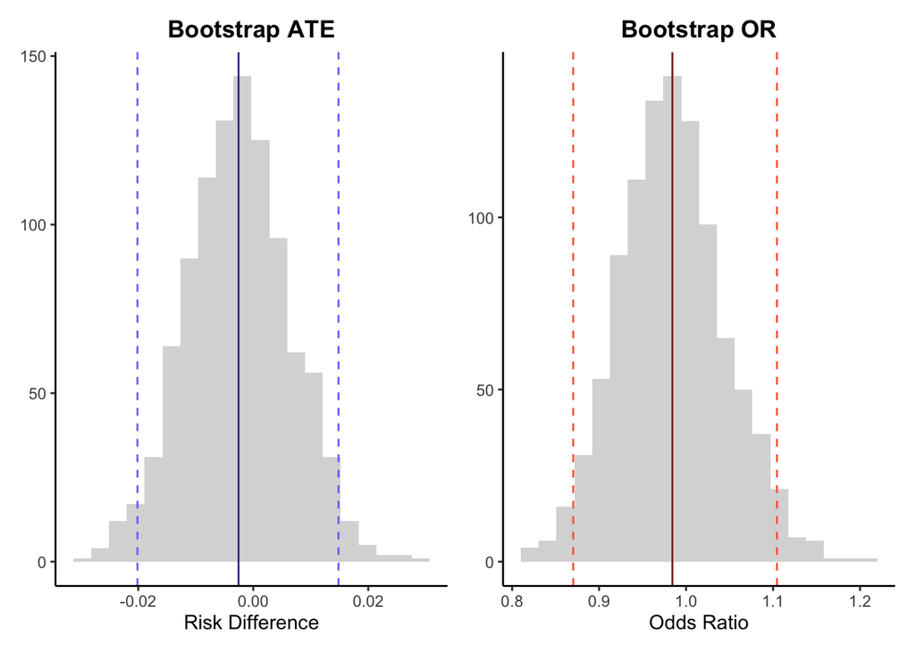

```r
# Visualisation
boots_df <- data.frame(
  ATE = ATE_boot,
  OR = OR_boot
)

ATE_plot <- ggplot(boots_df, aes(x = ATE)) +
  geom_histogram(bins = 20, fill = "grey85") +
  labs(title = "Bootstrap ATE",
       x = "Risk Difference",
       y = NULL) +
  geom_vline(
    aes(xintercept = mean(ATE_boot)),
    color = "slateblue4", linewidth = 0.5) +
  geom_vline(
    aes(xintercept = quantile(ATE_boot, 0.025)),
    color = "slateblue1", linewidth = 0.5, linetype ="dashed") +
    geom_vline(
    aes(xintercept = quantile(ATE_boot, 0.975)),
    color = "slateblue1", linewidth = 0.5, linetype ="dashed") +
  theme(panel.background = element_blank(),
        plot.title = element_text(face = "bold", hjust = 0.5),
        axis.line = element_line(colour = 'black', linewidth = 0.5))

OR_plot <- ggplot(boots_df, aes(x = OR)) +
  geom_histogram(bins = 20, fill = "grey85") +
  labs(title = "Bootstrap OR",
       x = "Odds Ratio",
       y = NULL) +
  geom_vline(
    aes(xintercept = mean(OR_boot)),
    color = "tomato4", linewidth = 0.5) +
  geom_vline(
    aes(xintercept = quantile(OR_boot, 0.025)),
    color = "tomato1", linewidth = 0.5, linetype ="dashed") +
    geom_vline(
    aes(xintercept = quantile(OR_boot, 0.975)),
    color = "tomato1", linewidth = 0.5, linetype ="dashed") +
  theme(panel.background = element_blank(),
        plot.title = element_text(face = "bold", hjust = 0.5),
        axis.line = element_line(colour = 'black', linewidth = 0.5))

wrap_plots(list(ATE_plot, OR_plot))
```

## Summary G-computation

```r
# Create a summary data frame
results_table <- data.frame(
  Metric = c("Average Treatment Effect (ATE)", "Odds Ratio (OR)"),
  Estimate = c(mean(ATE_boot, na.rm = TRUE), mean(OR_boot, na.rm = TRUE)),
  Lower_CI = c(quantile(ATE_boot, 0.025, na.rm = TRUE), quantile(OR_boot, 0.025, na.rm = TRUE)),
  Upper_CI = c(quantile(ATE_boot, 0.975, na.rm = TRUE), quantile(OR_boot, 0.975, na.rm = TRUE))
)

# Format for display
results_table$Formatted <- sprintf("%.3f (95%% CI: %.3f, %.3f)",
                                   results_table$Estimate,
                                   results_table$Lower_CI,
                                   results_table$Upper_CI)

print(results_table[, c("Metric", "Formatted")])
```

```
##                           Metric                      Formatted
## 1 Average Treatment Effect (ATE) -0.003 (95% CI: -0.020, 0.015)
## 2                Odds Ratio (OR)   0.984 (95% CI: 0.870, 1.104)
```

# Propensity Model

## Propensity Score Weighting (IPW)

```r
# Estimate propensity scores
propensity_model <- glm(
  medhyper ~ MAP + age + sex + comorbidities +  adiposity + current.smoking,
  family = binomial,
  data = data
)
summary(propensity_model)
```

```
##
## Call:
## glm(formula = medhyper ~ MAP + age + sex + comorbidities + adiposity +
##     current.smoking, family = binomial, data = data)
##
## Coefficients:
##                  Estimate Std. Error z value Pr(>|z|)
## (Intercept)     -6.846411   0.312792 -21.888  < 2e-16 ***
## MAP              0.019828   0.002140   9.265  < 2e-16 ***
## age              0.064488   0.004351  14.822  < 2e-16 ***
## sexmale         -0.243817   0.050850  -4.795 1.63e-06 ***
## comorbidities1   1.784965   0.070246  25.410  < 2e-16 ***
## comorbidities2   1.981019   0.142272  13.924  < 2e-16 ***
## adiposity        0.236703   0.013478  17.563  < 2e-16 ***
## current.smoking  0.041284   0.069260   0.596    0.551
## ---
## Signif. codes:  0 '***' 0.001 '**' 0.01 '*' 0.05 '.' 0.1 ' ' 1
##
## (Dispersion parameter for binomial family taken to be 1)
##
##     Null deviance: 12043  on 10069  degrees of freedom
## Residual deviance: 10093  on 10062  degrees of freedom
## AIC: 10109
##
## Number of Fisher Scoring iterations: 4
```

```r
# Add propensity scores to dataset
data_with_ps <- propensity_model |>
  augment(type.predict = "response", data = data)

# rename for convenience
data_with_ps$ps <- data_with_ps$.fitted
```

## Positivity check

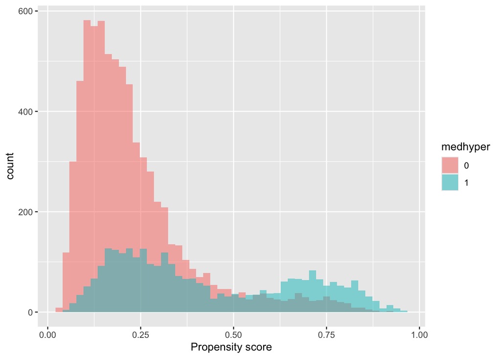

```r
# Histogram
ggplot(data_with_ps, aes(ps, fill = factor(medhyper))) +
  geom_histogram(bins = 50, position = "identity", alpha = 0.5) +
  labs(x = "Propensity score", fill = "medhyper")
```

```r
# Check range of propensity scores
data_with_ps |>
  group_by(medhyper) |>
  summarise(min_ps = min(ps), max_ps = max(ps))
```

```
## # A tibble: 2 × 3
##   medhyper min_ps max_ps
##      <dbl>  <dbl>  <dbl>
## 1        0 0.0301  0.926
## 2        1 0.0479  0.958
```

The histograms and range show adequate overlap between treatment status.

## Stabilised weights

To reduce the effect of extreme weights, we decide to use stabilised weights instead.

```r
# Numerator model for stabilized weights (marginal probability of treatment)
numerator_model <- glm(medhyper ~ 1, family = binomial, data = data_with_ps)

p_treat <- fitted.values(numerator_model)

# Stabilized weights
data_with_ps$sw <- ifelse(
  data_with_ps$medhyper == 1,
  p_treat / data_with_ps$ps,
  (1 - p_treat) / (1 - data_with_ps$ps)
)

summary(data_with_ps$sw)
```

```
##    Min. 1st Qu.  Median    Mean 3rd Qu.    Max.
##  0.2978  0.7970  0.8769  0.9973  1.0286  9.6211
```

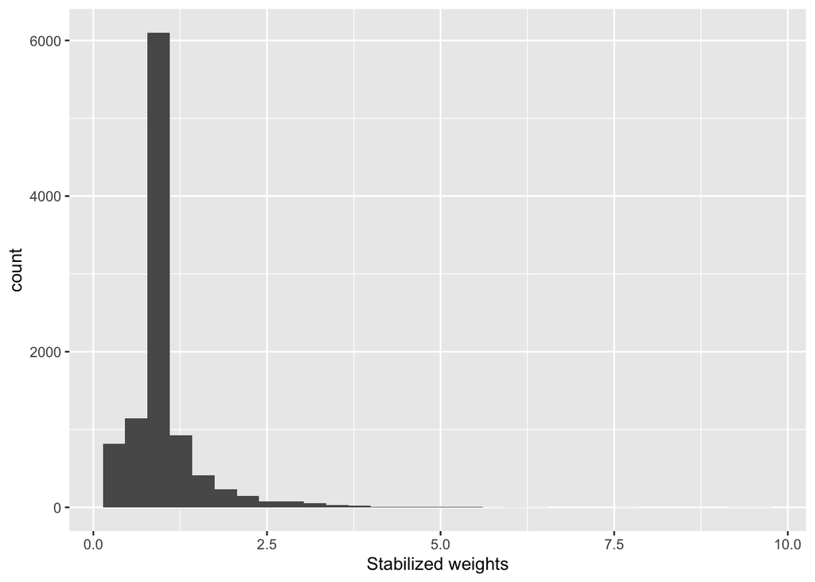

```r
# Check for extreme weights
ggplot(data_with_ps, aes(sw)) +
  geom_histogram() +
  labs(x = "Stabilized weights")
```

We see that we have some extreme weights. To mitigate this issue further, we decide to truncate above the 99th percentile.